# Rep. research assignment 2

Raul

17th december 2014

# *Severe Weather Events and their impact on Public Health and Economy*

## Data Processing

**Performed steps**:  
* Get and load the data  
* Remove some unused variables to optimise memory usage  
* Remove original data to optimise memory usage

```r
# check to see if the data set exists; if not, get it...
if (!file.exists('repdata-data-StormData.csv.bz2')) {

# download the zip file and unzip
        file.url<-'https://d396qusza40orc.cloudfront.net/repdata%2Fdata%2FStormData.csv.bz2'
        download.file(file.url,destfile='repdata-data-StormData.csv.bz2', method="curl")
}
# load the data
storm_data_bz <- bzfile("repdata-data-StormData.csv.bz2", open = "r")
storm_data_raw <- read.table(storm_data_bz, header = TRUE, sep = ",")
close(storm_data_bz)
remove(storm_data_bz)

# remove unnecessary columns
good_columns <- c("EVTYPE",                  # Event type
                  "FATALITIES", "INJURIES",  # Fatalities and Injuries
                  "PROPDMG", "PROPDMGEXP",   # Property damange and exponential
                  "CROPDMG", "CROPDMGEXP")   # Crop damage and exponential
storm_data <- storm_data_raw[,good_columns]
summary(storm_data)
```

```
##                EVTYPE         FATALITIES          INJURIES
##  HAIL             :288661   Min.   :  0.0000   Min.   :   0.0000
##  TSTM WIND        :219940   1st Qu.:  0.0000   1st Qu.:   0.0000
##  THUNDERSTORM WIND: 82563   Median :  0.0000   Median :   0.0000
##  TORNADO          : 60652   Mean   :  0.0168   Mean   :   0.1557
##  FLASH FLOOD      : 54277   3rd Qu.:  0.0000   3rd Qu.:   0.0000
##  FLOOD            : 25326   Max.   :583.0000   Max.   :1700.0000
##  (Other)          :170878
##     PROPDMG          PROPDMGEXP        CROPDMG          CROPDMGEXP
##  Min.   :   0.00          :465934   Min.   :  0.000          :618413
##  1st Qu.:   0.00   K      :424665   1st Qu.:  0.000   K      :281832
##  Median :   0.00   M      : 11330   Median :  0.000   M      :  1994
##  Mean   :  12.06   0      :   216   Mean   :  1.527   k      :    21
##  3rd Qu.:   0.50   B      :    40   3rd Qu.:  0.000   0      :    19
##  Max.   :5000.00   5      :    28   Max.   :990.000   B      :     9
##                    (Other):    84                     (Other):     9
```

```r
# remove original data to save space
remove(storm_data_raw)
```

- Calculate the damage
- Add property damage and crop damage to get the total damage
- Calculate total fatalities and injuries

```r
# calculate the total damage
levels(storm_data$PROPDMGEXP) <- c(
  "1", "1", "1", "1", "1", "1", "1", "1", "1", "1", "1", "1", "1",
  "1000000000", "1", "1", "1000", "1000000", "1000000")
levels(storm_data$CROPDMGEXP) <- c(
  "1", "1", "1", "1", "1000000000", "1000",
  "1000", "1000000", "1000000")
storm_data$PROPDMG <- storm_data$PROPDMG *
  as.integer(as.character(storm_data$PROPDMGEXP))
storm_data$CROPDMG <- storm_data$CROPDMG *
  as.integer(as.character(storm_data$CROPDMGEXP))
storm_data$DAMAGE <- storm_data$PROPDMG + storm_data$CROPDMG

# calculate total injuries and fatalities
storm_data$HEALTH <- storm_data$INJURIES + storm_data$FATALITIES
```

## Results

### Impact on Population health

Across the United States, which types of events are most harmful with respect to population health?

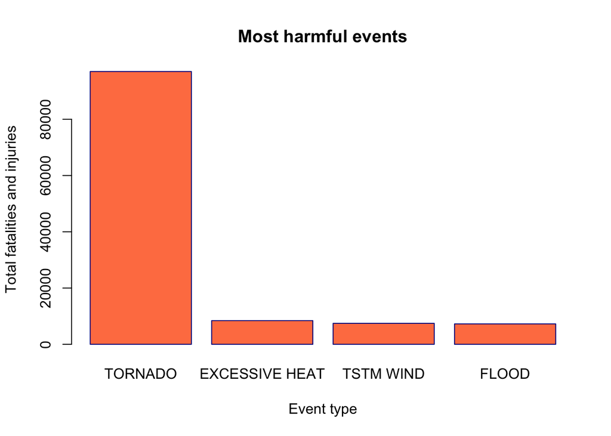

```r
total <- sort(tapply(storm_data$HEALTH, storm_data$EVTYPE, sum),decreasing = T)
barplot(head(total,4),
        main="Most harmful events",
        xlab="Event type",
        ylab="Total fatalities and injuries",
        border="dark blue",
        col=c("coral"))
```

```r
max(total)
```

```
## [1] 96979
```

As we can see in this plot, Tornados caused the highest number of damage (96.980 fatalities and injuries), significantly more than any other type of events such as excessive heat or wind which are the second most damaging events for fatalities and injuries respectively.

### Impact on Economy

Across the United States, which types of events have the greatest economic consequences?

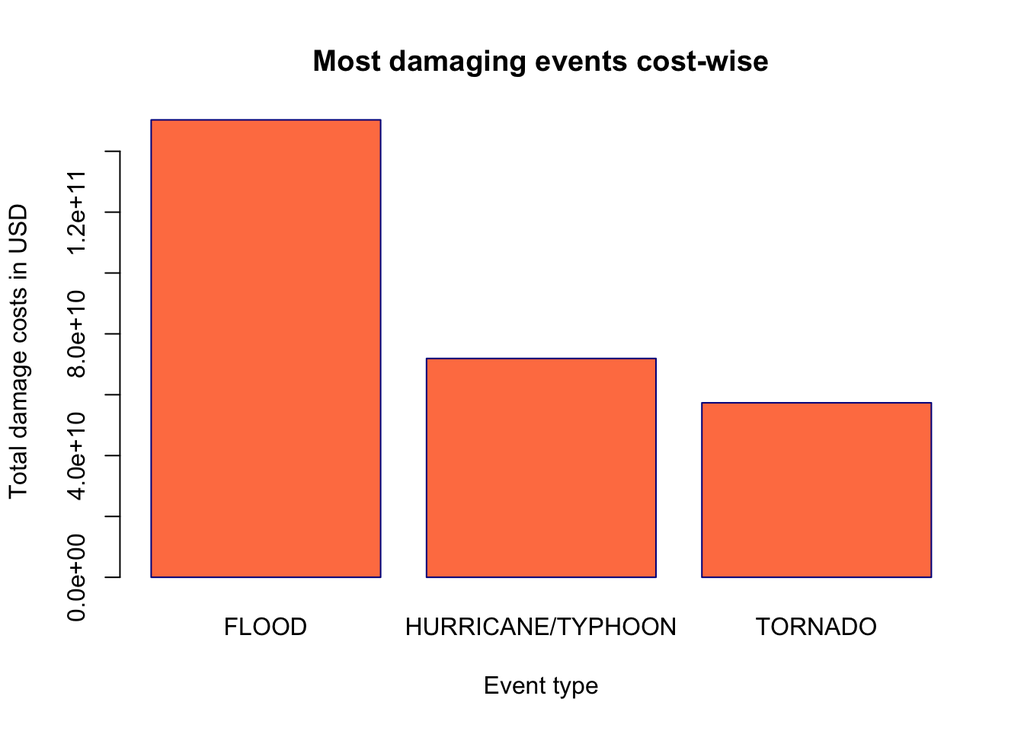

```r
total <- sort(tapply(storm_data$DAMAGE, storm_data$EVTYPE, sum), decreasing = T)
barplot(head(total,3),
        main="Most damaging events cost-wise",
        xlab="Event type",
        ylab="Total damage costs in USD",
        border="dark blue",
        col=c("coral"))
```

```r
max(total)
```

```
## [1] 150319678257
```

As shown in this second plot, Floodings caused the biggest damage: over 150.000 million USD which is higher than the damage due to the second and third most damaging events (hurricanes and tornados) together.